# BAN422: Visualization in R

### Jacoby: quantile-quantile plots

Quantile-quantile plots require the choice of a theoretical distribution, and as Deepayan Sarkar says, the ECDF plot uses a uniform theoretical distribution, so is a Uniform QQ plot in a different orientation:

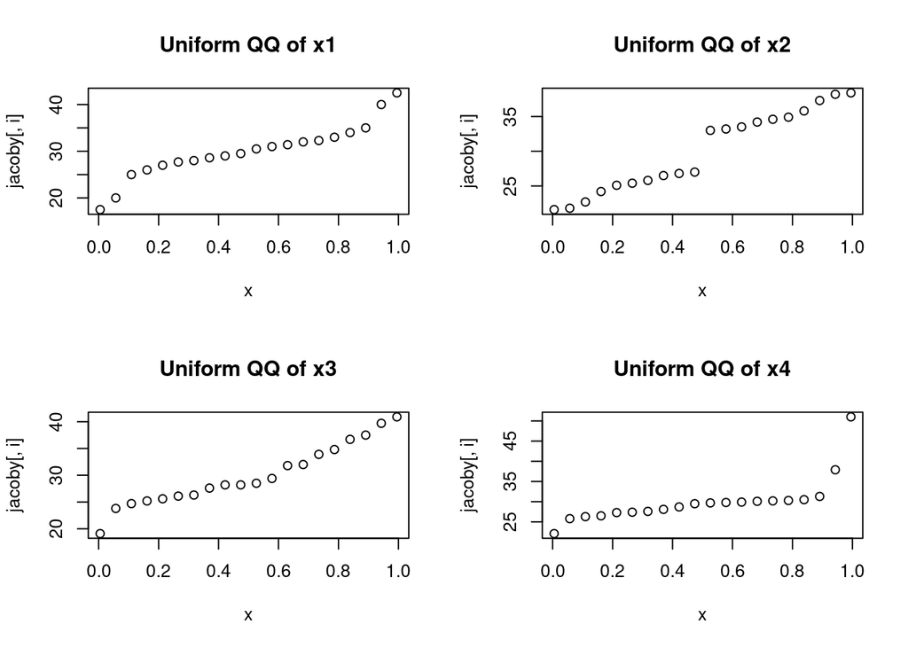

```r
oldpar <- par(no.readonly=TRUE)
par(mfrow=c(2,2))
x <- qunif(ppoints(100))
for (i in 1:4) {
  qqplot(x=x, y=jacoby[,i])
  title(main=paste("Uniform QQ of x",
    i, sep=""))
}
```

```r
par(oldpar)
```

The `qqnorm()` function gives a Normal QQ plot directly:

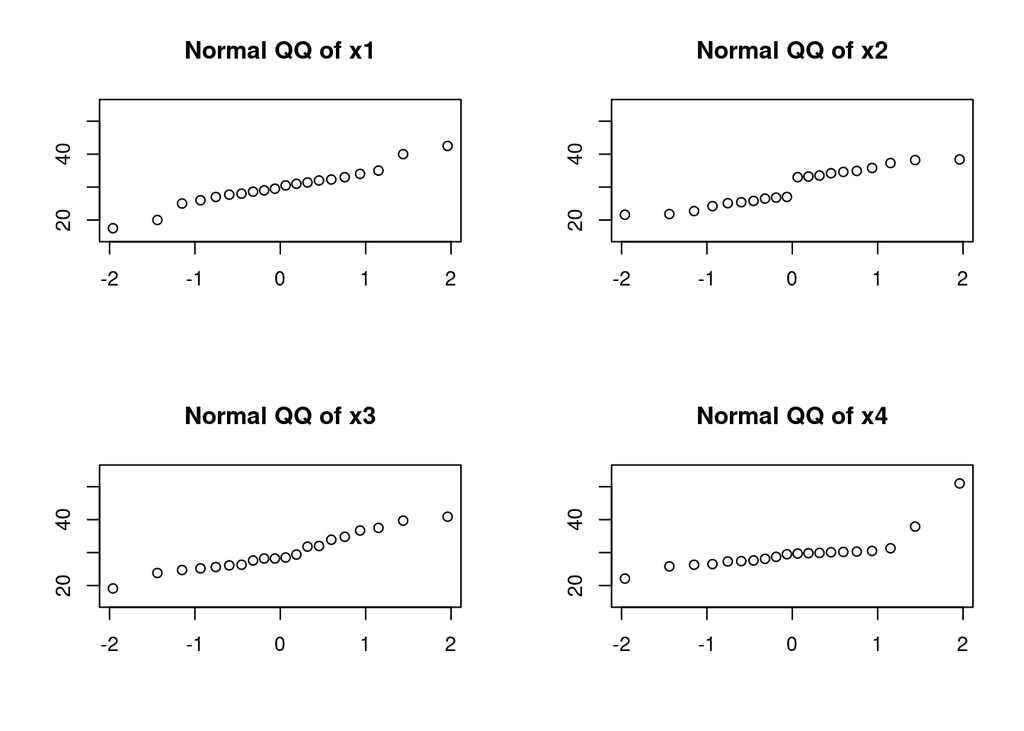

```r
oldpar <- par(no.readonly=TRUE)
par(mfrow=c(2,2))
for (i in 1:4) {
  qqnorm(y=jacoby[,i], xlab="", ylab="",
    ylim=c(15, 55), main="")
  title(main=paste("Normal QQ of x",
    i, sep=""))
}
```

```r
par(oldpar)
```

In **lattice**, `qqmath()` takes a `distribution` argument:

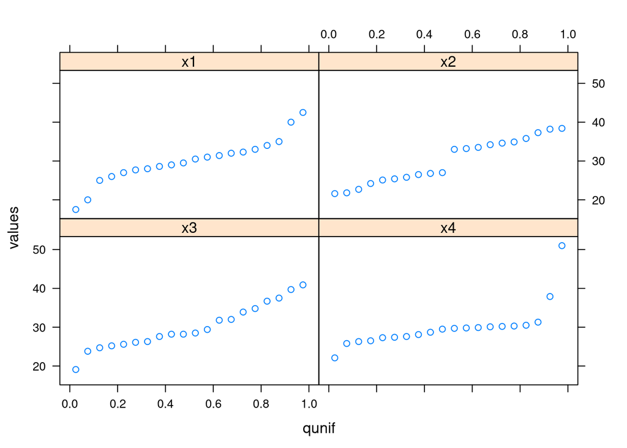

```r
qqmath(~ values | ind, data=jacobyS,
  distribution=qunif,
  index.cond=list(c(3,4,1,2)))
```

so this reproduces `qqnorm`:

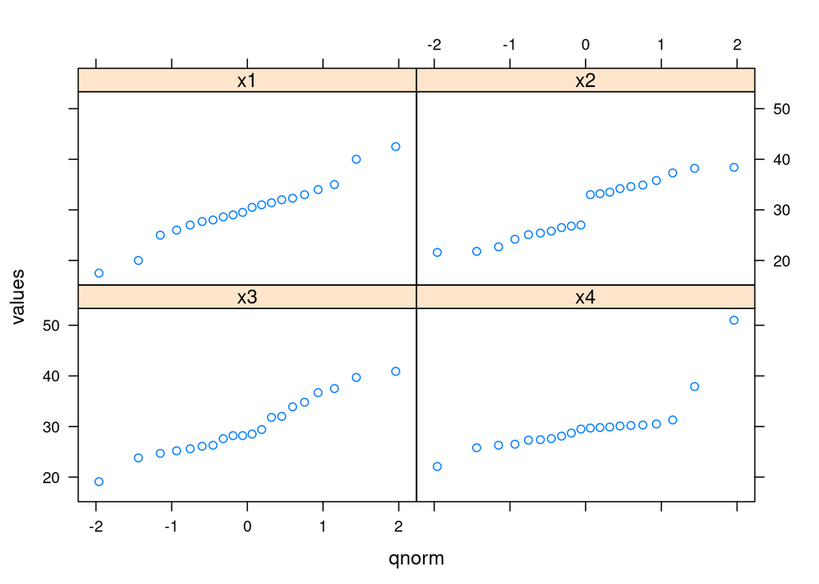

```r
qqmath(~ values | ind, data=jacobyS,
  distribution=qnorm,
  index.cond=list(c(3,4,1,2)))
```

In ggplot, the `stat_qq()` operator is used with a specified distribution function, here Uniform:

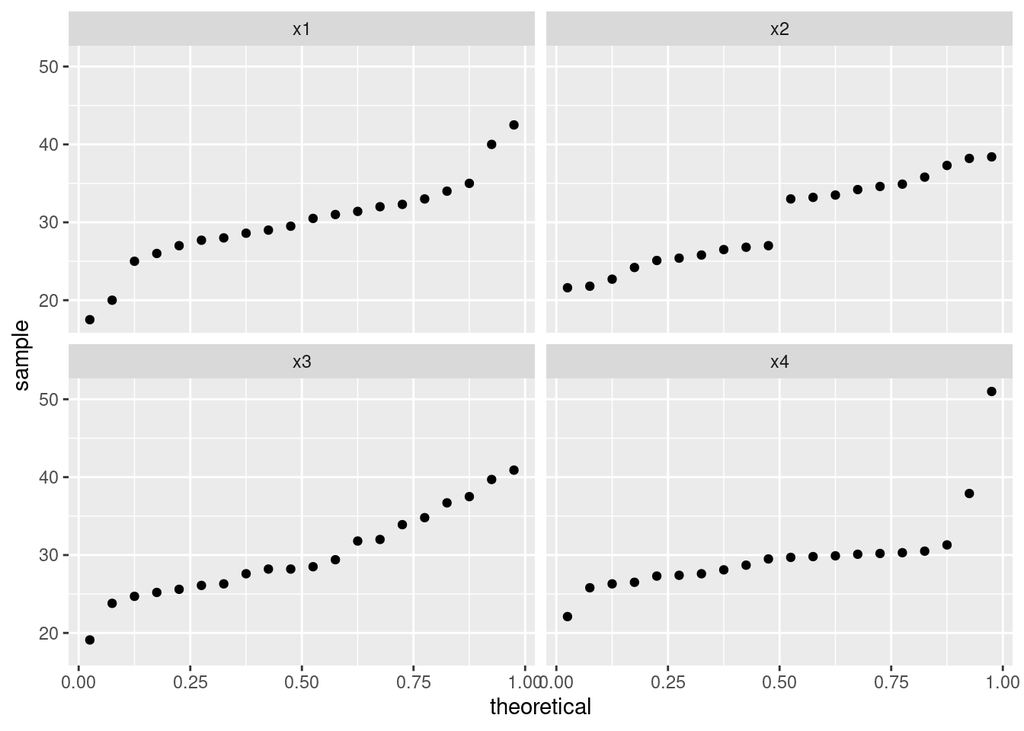

```r
ggplot(jacobyS, aes(sample=values)) +
  stat_qq(distribution=qunif) +
  facet_wrap(~ ind, ncol=2)
```

and for Normal QQ plots

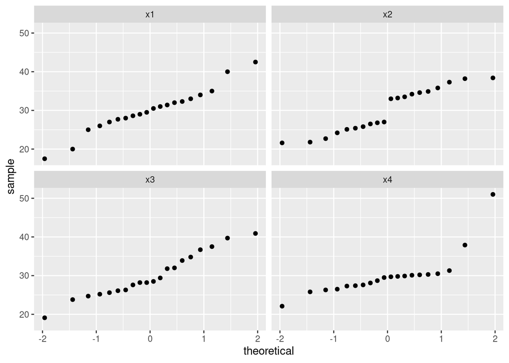

```r
ggplot(jacobyS, aes(sample=values)) +
  stat_qq(distribution=qnorm) +
  facet_wrap(~ ind, ncol=2)
```

# Ihaka Lecture 3, 2018

### Alberto Cairo

[Visual trumpery: How charts lie - and how they make us smarter](https://www.youtube.com/watch?v=Cd046xZhO_8)

# Ihaka Lecture 1, 2018

### Dianne Cook

[Myth busting and apophenia in data visualisation: Is what you see really there?](https://www.youtube.com/watch?v=coGeZIHCk38)

## PISA data subset

- In the talk, the [PISA 2015 data set](http://www.oecd.org/pisa/data/2015database/) is mentioned
- An OECD [technical report](https://www.oecd.org/pisa/pisaproducts/PISA%202012%20Technical%20Report_Chapter%209.pdf) describes in more detail how the plausible values from fitted item response models are generated, in 2015 10 PVs for each participant, 5 PVs before
- In the talk, Di Cook uses the first plausible value; we can check what she does in the code blocks in her [slides](https://raw.githubusercontent.com/dicook/Ihaka-talk/master/index.Rmd)

### Importing the SPSS data

The data provided for the over 500,000 individual students include over 900 variables, but we’ll look at the score plausible values (PV), taking means and standard deviations of the 10 PVs given for math, reading and science for each student. In the talk, only PV1 was used. We reread the data to get three-letter country codes.

```r
library(foreign)
QQQ <- read.spss("data/CY6_MS_CMB_STU_QQQ.sav", to.data.frame=TRUE)
QQQ1 <- QQQ[,c(1,2,4,29,30,35,64,810:839,920)]
QQQ1$math_mean <- apply(as.matrix(QQQ1[,8:17]), 1, mean)
QQQ1$math_sd <- apply(as.matrix(QQQ1[,8:17]), 1, sd)
QQQ1$read_mean <- apply(as.matrix(QQQ1[,18:27]), 1, mean)
QQQ1$read_sd <- apply(as.matrix(QQQ1[,18:27]), 1, sd)
QQQ1$sci_mean <- apply(as.matrix(QQQ1[,28:37]), 1, mean)
QQQ1$sci_sd <- apply(as.matrix(QQQ1[,28:37]), 1, sd)
QQQ <- read.spss("data/CY6_MS_CMB_STU_QQQ.sav", to.data.frame=TRUE, use.value.labels=FALSE)
QQQ1$CNT_vl <- QQQ1$CNT
QQQ1$CNT <- QQQ$CNT
saveRDS(QQQ1, file="dicook/pisa_raw_subset.rds")
```

### Subsetting the scores

Next we change some country codes to use ISO 3-letter alphabetical codes, and drop three entities as in the original script, and re-save this observation subset.

```r
QQQ1 <- readRDS("dicook/pisa_raw_subset.rds")
recodes <- c("'QES'='ESP'", "'QCH'='CHN'", "'QAR'='ARG'", "'TAP'='TWN'")
for (str in recodes) QQQ1$CNT <- car::recode(QQQ1$CNT, str)
QQQ2 <- droplevels(QQQ1[!(as.character(QQQ1$CNT) %in% c("QUC", "QUD", "QUE")),])
library(ISOcodes)
data("ISO_3166_1")
scores <- merge(QQQ2, ISO_3166_1[,c("Alpha_3", "Name")], by.x="CNT", by.y="Alpha_3", all.x=TRUE)
scores$Name[scores$CNT == "KSV"] <- "Kosovo"
saveRDS(scores, file="dicook/pisa_subset.rds")
```

### Adding country codes and names

Some of this repeats the steps above, and could be rationalsed. It is intended to yield a helper object listing countries and country codes with numbers of students, hence the use of `table()` and `aggregate()`.

```r
QQQ1 <- readRDS("dicook/pisa_raw_subset.rds")
recodes <- c("'QES'='ESP'", "'QCH'='CHN'", "'QAR'='ARG'", "'TAP'='TWN'")
CNT_count <- as.data.frame(table(QQQ1$CNT))
names(CNT_count) <- c("CNT", "n")
for(str in recodes) CNT_count$CNT <- car::recode(CNT_count$CNT, str)
CNT_count1 <- aggregate(CNT_count$n, list(CNT_count$CNT), sum)
CNT_count2 <- droplevels(CNT_count1[!(as.character(CNT_count1$Group.1) %in% c("QUC", "QUD", "QUE")),])
names(CNT_count2) <- c("CNT", "n")
library(ISOcodes)
data("ISO_3166_1")
countries <- merge(CNT_count2, ISO_3166_1, by.x="CNT", by.y="Alpha_3", all.x=TRUE)
countries$Name[countries$CNT == "KSV"] <- "Kosovo"
saveRDS(countries, file="dicook/countries.rds")
```

### Splitting into groups

Once these preparations are complete, we have about 500,000 observations on 10 PVs for each of three school subjects by binary gender and country, and use `split()` to make a list of two genders times 69 countries of student data frames.

```r
QQQ1 <- readRDS("dicook/pisa_subset.rds")
countries <- readRDS("dicook/countries.rds")
a0 <- split(QQQ1, list(QQQ1$CNT, QQQ1$ST004D01T))
```

### Aggregating weighted math means

Using `sapply()` on this list gives us one weighted mean of the means per student of maths PVs. We weight using normalized “senate” weights to permit comparisons between countries: “The senate weight makes the population of each country to be 5,000 to ensure an equal contribution by each of the countries in the analysis.”

```r
math_mean <- sapply(a0, function(x) weighted.mean(x$math_mean, w=x$SENWT))
n2 <- length(math_mean)/2
country <- sapply(strsplit(names(math_mean), "\\."), "[", 1)[1:n2]
co <- match(country, countries$CNT)
nms <- countries$Name[co]
gender <- factor(sapply(strsplit(names(math_mean), "\\."), "[", 2))[1:n2]
o <- order(math_mean[1:n2])
```

### Math means Cleveland dotchart

The workhorse is a Cleveland dotchart, which shows one point per math mean per gender and country. Standard dotcharts would show either one grouping category, or two separate dotcharts, one per gender, but here we wish to compare means of PV means:

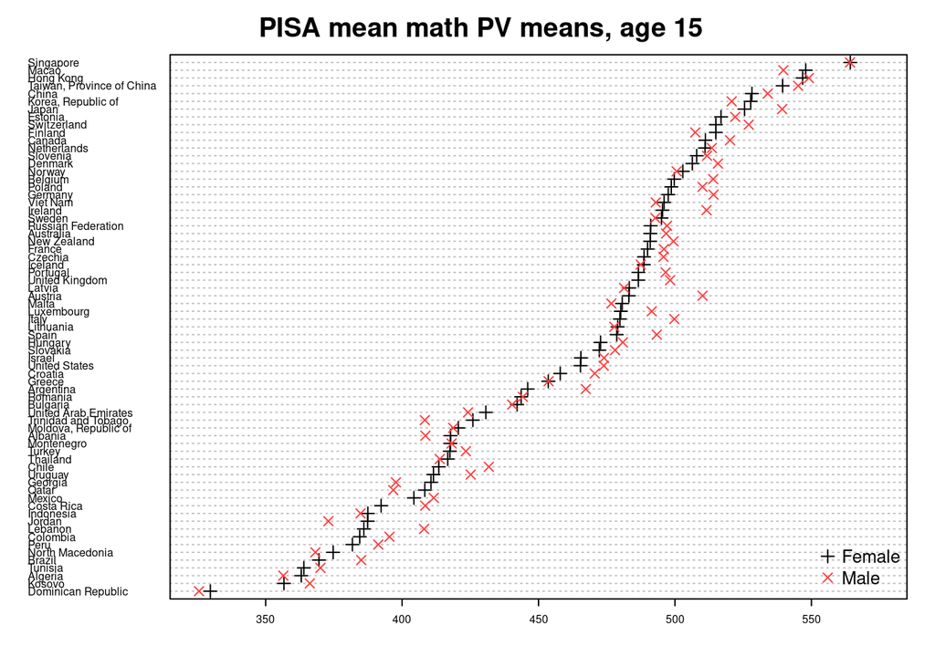

```r
dotchart(math_mean[o], label=nms[o], cex=0.5, pt.cex=0.9, pch=3, xlim=c(325, 575))
points(math_mean[n2+o], 1:n2, cex=0.9, pch=4, col="brown1")
legend("bottomright", legend=levels(gender), col=c("black", "brown1"), pch=3:4, pt.cex=0.9, bty="n", cex=0.8)
title("PISA mean math PV means, age 15")
```

### but what about a +/- 2 standard error caterpillar plot?

However, in much applied work, it is useful to see whether apparent differences are only apparent. The caterpillar plot is useful for this, it is like a dotplot, but adds lines usually showing a multiple of standard errors (here +/- 2). We use a weighted standard deviation and sums of weights to ensure that the means and standard errors are coherent. We can insert the lines using a `for()` loop:

```r
library(matrixStats)
sqn <- sqrt(sapply(a0, function(x) sum(x$SENWT)))
math_se <- sapply(a0, function(x) weightedSd(x$math_mean, w=x$SENWT))/sqn
```

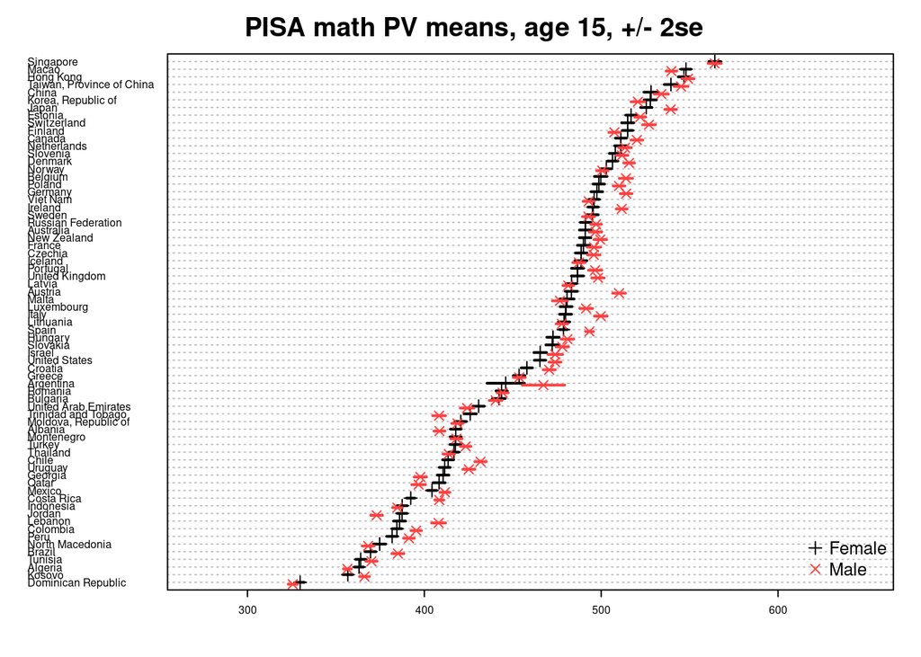

```r
dotchart(math_mean[o], label=nms[o], cex=0.5, pt.cex=0.9, pch=3, xlim=c(270, 650))
for (i in 1:n2) segments(x0=math_mean[o][i]-2*(math_se[o][i]), y0=i, x1=math_mean[o][i]+2*(math_se[o][i]), lwd=2)
points(math_mean[n2+o], (1:n2)-0.25, cex=0.9, pch=4, col="brown1")
for (i in 1:n2) segments(x0=math_mean[n2+o][i]-2*(math_se[n2+o][i]), y0=i-0.25, x1=math_mean[n2+o][i]+2*(math_se[n2+o][i]), lwd=2, col="brown1")
legend("bottomright", legend=levels(gender), col=c("black", "brown1"), pch=3:4, pt.cex=0.9, bty="n", cex=0.8)
title("PISA math PV means, age 15, +/- 2se")
```

### Aggregating weighted reading and science means

We repeat the simple comparative dotplot for the remaining school subjects:

```r
read_mean <- sapply(a0, function(x) weighted.mean(x$read_mean, w=x$SENWT))
ro <- order(read_mean[1:n2])
```

```r
sci_mean <- sapply(a0, function(x) weighted.mean(x$sci_mean, w=x$SENWT))
so <- order(sci_mean[1:n2])
```

### Reading means Cleveland dotchart

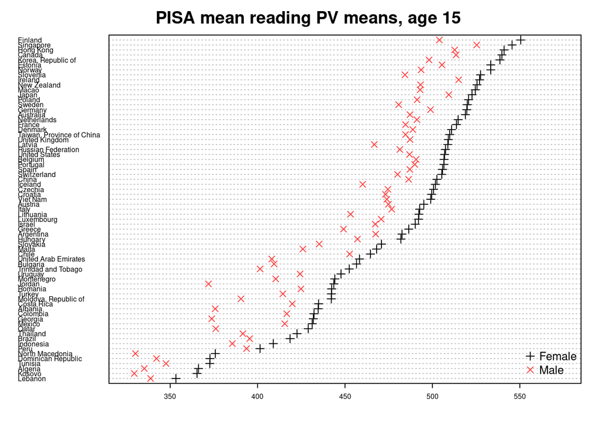

```r
dotchart(read_mean[ro], label=nms[ro], cex=0.5, pt.cex=0.9, pch=3, xlim=c(325, 575))
points(read_mean[n2+ro], 1:n2, cex=0.9, pch=4, col="brown1")
legend("bottomright", legend=levels(gender), col=c("black", "brown1"), pch=3:4, pt.cex=0.9, bty="n", cex=0.8)
title("PISA mean reading PV means, age 15")
```

### Science means Cleveland dotchart

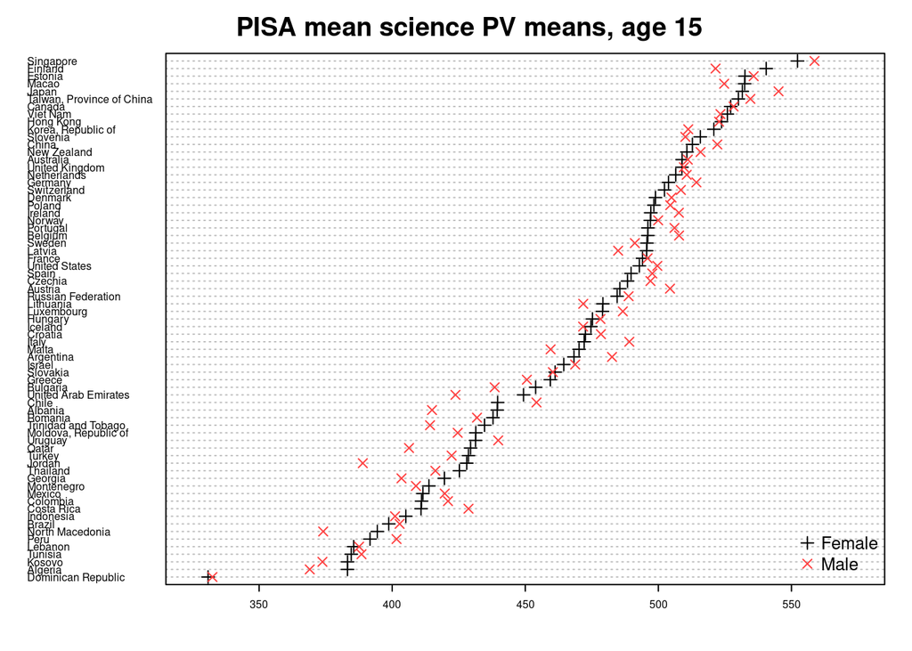

```r
dotchart(sci_mean[so], label=nms[so], cex=0.5, pt.cex=0.9, pch=3, xlim=c(325, 575))
points(sci_mean[n2+so], 1:n2, cex=0.9, pch=4, col="brown1")
legend("bottomright", legend=levels(gender), col=c("black", "brown1"), pch=3:4, pt.cex=0.9, bty="n", cex=0.8)
title("PISA mean science PV means, age 15")
```

### Mapping gaps Female-Male

As in the talk, we can make maps of the apparent gender gaps between the means of mean plausible values, first calculating the gaps and adding country identifiers:

```r
math_gap <- math_mean[1:n2] - math_mean[n2+(1:n2)]
read_gap <- read_mean[1:n2] - read_mean[n2+(1:n2)]
sci_gap <- sci_mean[1:n2] - sci_mean[n2+(1:n2)]
gaps <- data.frame(math_gap, read_gap, sci_gap, iso_a3=country,
  iso_a2=countries$Alpha_2[co])
```

### Country boundaries

We use a 1:50m set of country boundaries (in the 1:110m set, Singapore disappears).

```r
library(rnaturalearth)
library(rnaturalearthdata)
data(countries50)
library(sf)
countries50 <- st_as_sf(countries50)
```

### Using tmap for maps

We can `merge()` the gaps data with the country boundaries, and the **tmap** package to create the map. Tomorrow we’ll look at binning and colours. Using `ttm()`, we can toggle to an interactive format, using `last_map()` to recall the last generated map.

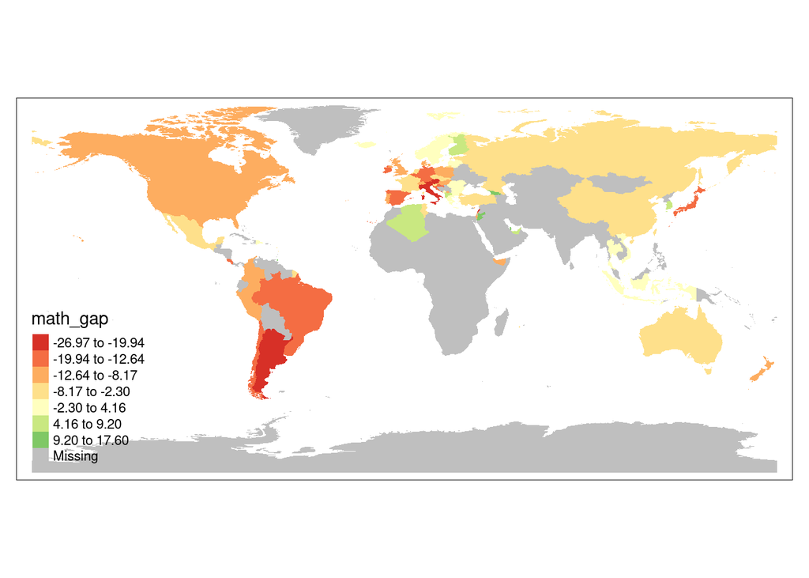

```r
world_gaps <- merge(countries50, gaps, by="iso_a2", all.x=TRUE)
library(tmap)
tm_shape(world_gaps) + tm_fill("math_gap", palette="div", n=7, style="jenks", midpoint=0)
```

```r
#ttm()
#last_map()
```

### Other points

- In the talk, boxplots are used to explore the variability between students by gender and country; here we tried a caterpillar plot. The PV means also flatten variability - would medians be more sensible?
- Could aspects of the PISA data set be used in thinking about projects?
- Other data sets are made available by Di Cook, and the **nullabor** package seems interesting, and maybe could also work (well) for projects, maybe also varying graphical representation?

# Somewhere over the Rainbow

### New base palettes coming

[A New palette() for R](https://developer.r-project.org/Blog/public/2019/11/21/a-new-palette-for-r/index.html)

### Colour palettes

- Zeileis and others have discussed the opportunities to be found for effective visual communication in statistical graphics using colours; we distinguish between sequential, diverging and qualitative palettes
- There are differences in opinions with regard to colour look-up (continuous or discrete) between implementations - **RColorBrewer** is discrete
- There are several palettes, such as `rainbow`, `cm.colors`, `heat.colors` and others in **grDevices**
- Other packages include **viridis**, **colorspace**, and further palettes provided in plotting methods (`sf.colors` uses `sp::bpy.colors`)

### ColorBrewer

Fortunately, the **RColorBrewer** package gives by permission access to the ColorBrewer palettes accesible from the [ColorBrewer](http://colorbrewer2.org) website. Note that ColorBrewer limits the number of classes tightly, only 3–9 sequential classes

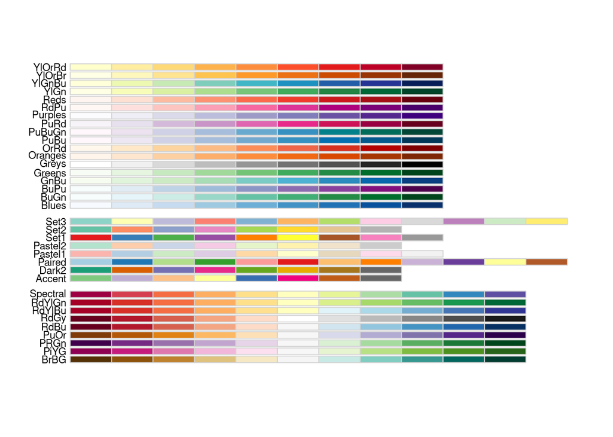

```r
library(RColorBrewer)
opar <- par(cex=0.7)
display.brewer.all()
```

```r
par(opar)
```

### Viridis

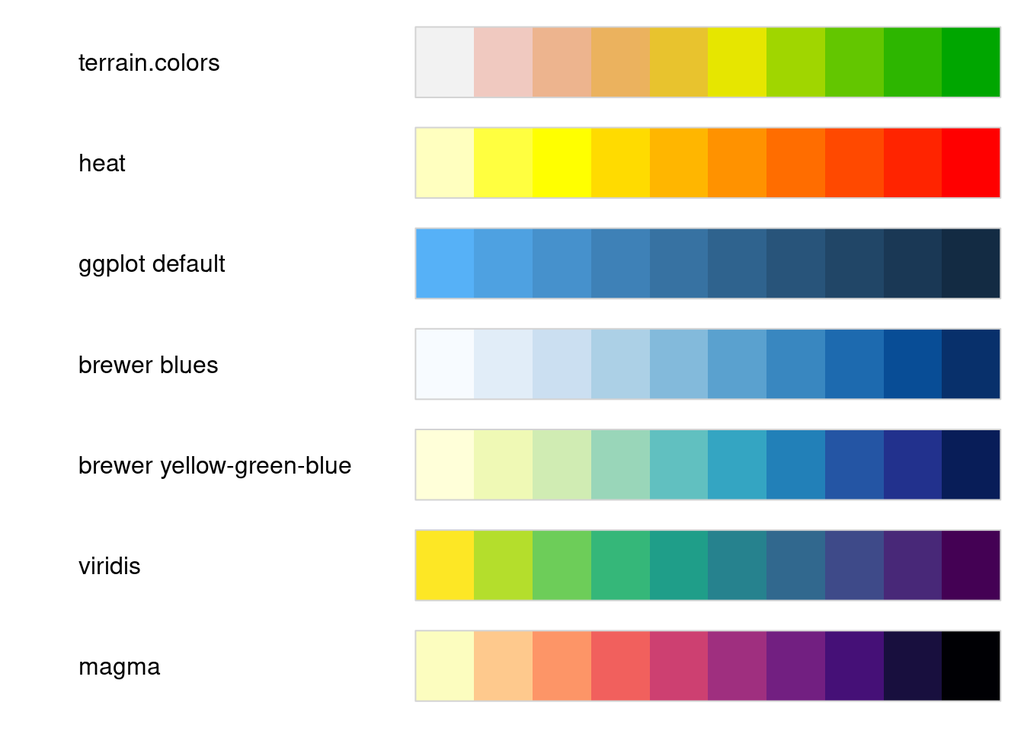

```r
suppressPackageStartupMessages(library(viridis))
library(colorspace)
library(ggplot2)
#devtools::install_github("wilkelab/cowplot")
#install.packages("colorspace", repos = "http://R-Forge.R-project.org")
#devtools::install_github("clauswilke/colorblindr")
library(colorblindr)
n_col <- 10
swatchplot(
"terrain.colors"=rev(terrain.colors(n_col)),
"heat"=rev(heat.colors(n_col)),
"ggplot default"=rev(scales::seq_gradient_pal(low = "#132B43", high = "#56B1F7", space = "Lab")(seq(0, 1, length=n_col))),
"brewer blues"=scales::gradient_n_pal(scales::brewer_pal(type="seq")(9))(seq(0, 1, length=n_col)),
"brewer yellow-green-blue"=scales::gradient_n_pal(scales::brewer_pal(type="seq", palette = "YlGnBu")(9))(seq(0, 1, length=n_col)),
"viridis"=rev(viridis(n_col)),
"magma"=rev(magma(n_col))
)
```

### Cartography

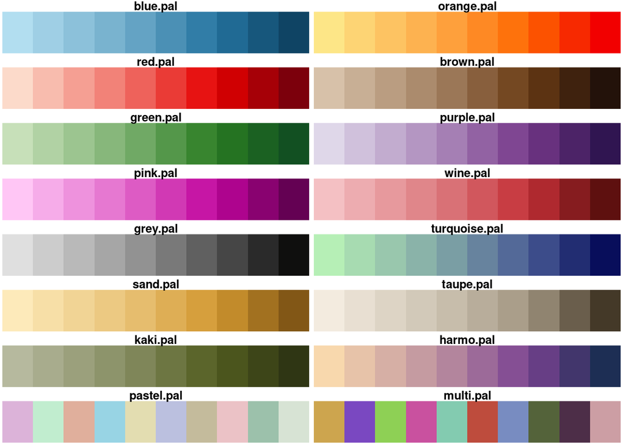

```r
suppressPackageStartupMessages(library(cartography))
display.carto.all(n = 10)
```

### colorspace and HCLWizard

- The **colorspace** package provides `choose_palette()` to choose HCL palettes interactively; it returns a palette function.
- [HCL-Based Color Palettes in grDevices](https://developer.r-project.org/Blog/public/2019/04/01/hcl-based-color-palettes-in-grdevices/index.html)
- The **colorblindr** from github provided the `swatchplot()` function to show colour swatches; it also provided an Okabe-Ito qualitative palette as `palette_OkabeIto`

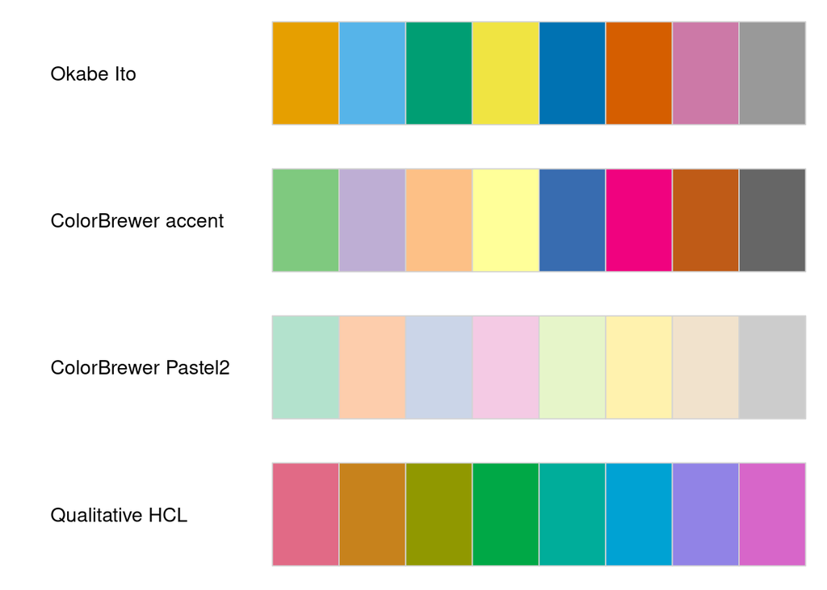

```r
n_col <- 8
swatchplot(
  "Okabe Ito"=palette_OkabeIto,
  "ColorBrewer accent"=brewer.pal(n_col, "Accent"),
  "ColorBrewer Pastel2"=brewer.pal(n_col, "Pastel2"),
  "Qualitative HCL"=qualitative_hcl(n_col)
)
```

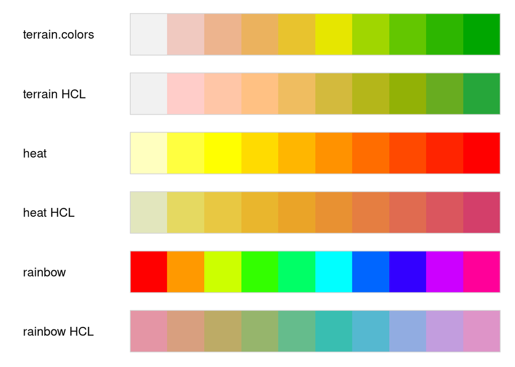

```r
n_col <- 10
swatchplot(
"terrain.colors"=rev(terrain.colors(n_col)),
"terrain HCL"=rev(terrain_hcl(n_col)),
"heat"=rev(heat.colors(n_col)),
"heat HCL"=rev(heat_hcl(n_col)),
"rainbow"=rainbow(n_col),
"rainbow HCL"=rainbow_hcl(n_col)
)
```